# Post-hoc Analysis of PrP/Prion Histology ML Predictions

Brain-region-specific deposition patterns across GtDeer, GtElk, and control mice

Eliud R. Rivas Hernandez

2026-06-11

# 1 Project description

This report performs a **post-hoc analysis** of the output of an unsupervised / weakly-supervised ML image-analysis pipeline applied to PrP (prion protein) histology images. The goal is to evaluate whether **image-level predictions reveal brain-region-specific patterns of PrP deposition**, and whether those patterns differ across experimental groups — in particular the cervid-prion genotypes **GtDeer** and **GtElk** versus **controls**.

> **Interpretation caveats** Everything here is *post-hoc* and based on ML predictions, not independent biological validation. Results identify **candidate** brain regions associated with disease-like prediction patterns; they are hypotheses for follow-up, not definitive findings. Small per-cell sample sizes are flagged throughout.

# 2 How to run

From the project root, open the Rmd inside `pipeline/` and knit it, or run:

```bash
cd pipeline
Rscript -e "rmarkdown::render('posthoc_analysis_corrected.Rmd')"
```

Required R packages: `tidyverse`, `janitor`, `stringr`, `scales`, `rmarkdown`, and `knitr`. If needed, install them once with:

```r
install.packages(c("tidyverse", "janitor", "stringr", "scales", "rmarkdown", "knitr"))
```

Expected folder layout:

```
project/
├── pipeline/
│   └── posthoc_analysis_corrected.Rmd
├── results/
│   └── predictions.csv
└── psthoc/
    ├── cleaned_predictions.csv
    ├── accuracy_by_region.csv
    └── plots/
```

# 3 Setup: libraries and output directory

```r
# Core tidyverse-style stack
library(tidyverse)   # dplyr, tidyr, stringr, ggplot2, readr, purrr
library(janitor)     # clean_names()
library(stringr)     # path parsing
library(scales)      # nice axis labels

# Optional helpers (loaded if available; pipeline degrades gracefully otherwise)
have_broom <- requireNamespace("broom", quietly = TRUE)
have_knitr <- requireNamespace("knitr", quietly = TRUE)

theme_set(theme_minimal(base_size = 12))

# Input is expected at ../results/predictions.csv when this Rmd is inside pipeline/.
# Outputs are written to ../psthoc so the original prediction results stay untouched.
output_dir <- params$output_dir
if (!dir.exists(output_dir)) dir.create(output_dir, recursive = TRUE)

plots_dir <- file.path(output_dir, "plots")
if (!dir.exists(plots_dir)) dir.create(plots_dir, recursive = TRUE)

# Small helper: save a ggplot as PNG into ../psthoc/plots
save_plot <- function(plot, filename, width = 8, height = 5, dpi = 150) {
  ggsave(file.path(plots_dir, filename), plot = plot,
         width = width, height = height, dpi = dpi)
  invisible(file.path(plots_dir, filename))
}
```

# 4 Data import (robust to filename)

```r
# Resolve the input file: try the param, then a couple of common variants.
candidate_paths <- c(
  params$input_csv,
  "../results/predictions.csv",
  "../results/prediction.csv"
)
input_path <- candidate_paths[file.exists(candidate_paths)][1]

if (is.na(input_path)) {
  stop(
    "Could not find the input CSV. Looked for: ",
    paste(unique(candidate_paths), collapse = ", "),
    ". Set params$input_csv to the correct path."
  )
}
message("Reading: ", input_path)

raw <- readr::read_csv(input_path, show_col_types = FALSE)

# Standardise column names (snake_case) for robustness to capitalisation/spacing
df <- raw %>% janitor::clean_names()
glimpse(df)
```

```
## Rows: 138
## Columns: 11
## $ filepath              <chr> "/projects/ka22popl@colostate.edu/qCMBRetreat26/…
## $ brain_region          <chr> "GtDeer", "GtDeer", "GtDeer", "controls", "contr…
## $ true_label            <chr> "GtDeer", "GtDeer", "GtDeer", "controls", "contr…
## $ predicted_label       <chr> "GtDeer", "GtDeer", "GtDeer", "controls", "contr…
## $ correct               <lgl> TRUE, TRUE, TRUE, TRUE, TRUE, TRUE, TRUE, TRUE, …
## $ ood_score             <dbl> 0.023169160, 0.012989700, 0.007278681, 0.0090208…
## $ potential_new_subtype <lgl> FALSE, FALSE, FALSE, FALSE, FALSE, FALSE, FALSE,…
## $ infection_score       <dbl> 0.000000000, 0.000000000, 0.013493635, 0.0000000…
## $ mean_dab_intensity    <dbl> 0.002471929, 0.035006827, 0.054304037, 0.0250453…
## $ clean_tissue_area     <dbl> 0.9663978, 0.9666351, 0.9670021, 0.9716281, 0.97…
## $ artifact_area         <dbl> 0.007309688, 0.008066996, 0.007776690, 0.0048826…
```

# 5 Column detection (robust to naming differences)

The pipeline does not assume exact column names. It searches for the columns it needs using flexible pattern matching and reports what it found.

```r
# Helper: find the first existing column whose name matches any of the patterns
find_col <- function(data, patterns) {
  nms <- names(data)
  for (p in patterns) {
    hit <- nms[str_detect(nms, regex(p, ignore_case = TRUE))]
    if (length(hit) > 0) return(hit[1])
  }
  NA_character_
}

# --- Detect the image-path column automatically ---------------------------
# Strategy: among character columns, pick the one whose values most look like
# file paths (contain "/" and end in an image extension). Fall back to name match.
detect_path_col <- function(data) {
  char_cols <- names(data)[map_lgl(data, is.character)]
  if (length(char_cols) == 0) return(NA_character_)
  score_path <- function(x) {
    x <- x[!is.na(x)]
    if (length(x) == 0) return(0)
    mean(str_detect(x, "/") &
         str_detect(x, regex("\\.(tif|tiff|png|jpg|jpeg|svs|ndpi)$", ignore_case = TRUE)))
  }
  scores <- map_dbl(data[char_cols], score_path)
  if (max(scores) > 0.5) return(char_cols[which.max(scores)])
  # fallback to name-based detection
  find_col(data, c("file_?path", "image_?path", "path", "file_?name", "image"))
}

path_col      <- detect_path_col(df)
true_col      <- find_col(df, c("^true_label$", "true_?label", "expected", "actual", "ground_?truth"))
pred_col      <- find_col(df, c("^predicted_label$", "pred(icted)?_?label", "prediction", "class"))
correct_col   <- find_col(df, c("^correct$", "is_correct", "correctness", "match"))
group_col_in  <- find_col(df, c("^brain_region$", "group", "genotype", "treatment", "condition"))
# Continuous / score columns (optional)
infection_col <- find_col(df, c("infection_score", "disease_score", "prp_?score"))
ood_col       <- find_col(df, c("ood_score", "ood", "outlier"))
subtype_col   <- find_col(df, c("new_?subtype", "potential_new"))

detected <- tibble::tibble(
  role = c("image_path", "true_label", "predicted_label", "correct",
           "incoming_group/brain_region", "infection_score", "ood_score", "new_subtype"),
  column = c(path_col, true_col, pred_col, correct_col,
             group_col_in, infection_col, ood_col, subtype_col)
)
detected
```

| role | column |
| --- | --- |
| image_path | filepath |
| true_label | true_label |
| predicted_label | predicted_label |
| correct | correct |
| incoming_group/brain_region | brain_region |
| infection_score | infection_score |
| ood_score | ood_score |
| new_subtype | potential_new_subtype |

```r
# Hard requirement: we MUST have a path column to recover the true brain region.
if (is.na(path_col)) {
  stop("No image-path column detected. A path/filename column is required to ",
       "extract the true brain region (e.g. .../septum_4x/...tif). ",
       "Please point params at a file containing image paths.")
}
message("Using image-path column: '", path_col, "'")
```

# 6 Data cleaning and brain-region extraction

The incoming `brain_region` column is **incorrect** — it holds experimental-group labels (e.g. `GtDeer`, `GtElk`, `controls`) rather than anatomical regions. The true region lives in the path, in the folder immediately above the file (e.g. `.../septum_4x/...`). We:

1. Preserve the original column as `original_brain_region_label`.
2. Extract the region folder, strip any magnification suffix (`_4x`, `_10x`, …).
3. **Normalise case** (so `Cerebellum_4x` and `cerebellum_4x` collapse to one region — this genuinely occurs in the data).

```r
# Generic region extractor: take the second-to-last path component (the folder
# that contains the image), strip a trailing magnification token, lowercase it.
extract_brain_region <- function(path) {
  parts <- str_split(path, "/")
  vapply(parts, function(p) {
    p <- p[p != ""]
    if (length(p) < 2) return(NA_character_)
    folder <- p[length(p) - 1]                       # e.g. "septum_4x" / "Cerebellum_4x"
    region <- str_remove(folder, regex("_\\d+x$", ignore_case = TRUE))  # strip _4x/_10x/_20x...
    str_to_lower(str_trim(region))                   # normalise case -> "septum","cerebellum"
  }, character(1))
}

# A tidy display label (Title Case) for plots/tables, distinct from the join key.
display_region <- function(x) str_to_title(x)

# Preserve the incoming mislabelled brain_region/group column when present.
# If no such column exists, create a placeholder so the rest of the report still runs.
if (!is.na(group_col_in) && group_col_in %in% names(df)) {
  df_clean <- df %>%
    rename(original_brain_region_label = !!sym(group_col_in))
} else {
  df_clean <- df %>%
    mutate(original_brain_region_label = NA_character_)
}

# Add corrected anatomical region extracted from the image path.
df_clean <- df_clean %>%
  mutate(
    image_path = .data[[path_col]],
    brain_region = extract_brain_region(image_path),
    brain_region_display = display_region(brain_region)
  )

# Experimental group: prefer the (correct) true_label; fall back to the original
# mislabelled column or to the group folder in the path (data/<group>/...).
group_from_path <- function(path) {
  m <- str_match(path, "/data/([^/]+)/")
  m[, 2]
}
if (!is.na(true_col) && true_col %in% names(df_clean)) {
  df_clean <- df_clean %>%
    mutate(experimental_group = .data[[true_col]])
} else {
  df_clean <- df_clean %>%
    mutate(experimental_group = original_brain_region_label)
}

df_clean <- df_clean %>%
  mutate(
    experimental_group = ifelse(is.na(experimental_group) | experimental_group == "",
                                group_from_path(image_path), experimental_group)
  )

# Normalise correctness to a logical, however it was encoded.
if (!is.na(correct_col)) {
  df_clean <- df_clean %>%
    mutate(correct = as.logical(
      dplyr::case_when(
        tolower(as.character(.data[[correct_col]])) %in% c("true","t","1","yes","correct") ~ "TRUE",
        tolower(as.character(.data[[correct_col]])) %in% c("false","f","0","no","incorrect") ~ "FALSE",
        TRUE ~ as.character(.data[[correct_col]])
      )
    ))
} else if (!is.na(true_col) && !is.na(pred_col)) {
  # Derive correctness if not provided but both labels exist.
  df_clean <- df_clean %>%
    mutate(correct = .data[[true_col]] == .data[[pred_col]])
} else {
  warning("No correctness column and cannot derive it; accuracy metrics will be skipped.")
  df_clean$correct <- NA
}
```

## 6.1 Defining the “disease-associated” prediction label

Predictions here are **genotype labels**, not an explicit disease/non-disease flag. We infer the disease-positive set as the predicted labels that are **not** control-like (matching `control`, `ctrl`, `wt`, `wild`). Everything else (`GtDeer`, `GtElk`, …) is treated as **disease-associated**. This assumption is stated explicitly and is easy to override below.

```r
control_pattern <- regex("control|ctrl|^wt$|wild", ignore_case = TRUE)

# >>> USER OVERRIDE POINT <<<
# If the automatic inference is wrong for your labels, hard-set these vectors:
#   disease_labels <- c("GtDeer", "GtElk")
#   control_labels <- c("controls")
if (!is.na(pred_col)) {
  pred_levels    <- sort(unique(na.omit(df_clean[[pred_col]])))
  control_labels <- pred_levels[str_detect(pred_levels, control_pattern)]
  disease_labels <- setdiff(pred_levels, control_labels)

  message("Inferred control label(s): ",
          ifelse(length(control_labels), paste(control_labels, collapse=", "), "<none>"))
  message("Inferred disease label(s): ",
          ifelse(length(disease_labels), paste(disease_labels, collapse=", "), "<none>"))

  if (length(disease_labels) == 0) {
    warning("Could not infer any disease-associated predicted label. ",
            "Define `disease_labels` manually in this chunk.")
  }

  df_clean <- df_clean %>%
    mutate(
      predicted_disease = .data[[pred_col]] %in% disease_labels,           # ML calls it disease
      group_is_control  = str_detect(experimental_group, control_pattern), # true control mouse
      group_class       = ifelse(group_is_control, "Control", "Disease")
    )
} else {
  warning("No predicted-label column; categorical disease-rate analysis skipped.")
}
```

# 7 Sanity checks

```r
cat("Number of rows:", nrow(df_clean), "\n")
```

```
## Number of rows: 138
```

```r
cat("Number of columns:", ncol(df_clean), "\n\n")
```

```
## Number of columns: 18
```

```r
cat("Column names:\n"); print(names(df_clean))
```

```
## Column names:
```

```
##  [1] "filepath"                    "original_brain_region_label"
##  [3] "true_label"                  "predicted_label"
##  [5] "correct"                     "ood_score"
##  [7] "potential_new_subtype"       "infection_score"
##  [9] "mean_dab_intensity"          "clean_tissue_area"
## [11] "artifact_area"               "image_path"
## [13] "brain_region"                "brain_region_display"
## [15] "experimental_group"          "predicted_disease"
## [17] "group_is_control"            "group_class"
```

```r
cat("\nMissing values per key column:\n")
```

```
##
## Missing values per key column:
```

```r
key_cols <- c("image_path","brain_region","experimental_group",
              true_col, pred_col, "correct", infection_col)
key_cols <- key_cols[!is.na(key_cols) & key_cols %in% names(df_clean)]
df_clean %>% summarise(across(all_of(key_cols), ~ sum(is.na(.)))) %>% as.data.frame()
```

| image_path | brain_region | experimental_group | true_label | predicted_label | correct | infection_score |
| --- | --- | --- | --- | --- | --- | --- |
| 0 | 0 | 0 | 0 | 0 | 0 | 0 |

```r
cat("\nUnique experimental groups:\n"); print(sort(unique(df_clean$experimental_group)))
```

```
##
## Unique experimental groups:
```

```
## [1] "controls" "GtDeer"   "GtElk"
```

```r
cat("\nUnique brain regions (cleaned):\n"); print(sort(unique(df_clean$brain_region)))
```

```
##
## Unique brain regions (cleaned):
```

```
## [1] "cerebellum"  "hippocampus" "midbrain"    "septum"
```

```r
cat("\nExamples: original path -> cleaned brain_region\n")
```

```
##
## Examples: original path -> cleaned brain_region
```

```r
df_clean %>%
  transmute(image_path, original_brain_region_label, brain_region) %>%
  group_by(brain_region) %>% slice_head(n = 1) %>% ungroup() %>%
  as.data.frame() %>% print(right = FALSE)
```

```
##   image_path
## 1 /projects/ka22popl@colostate.edu/qCMBRetreat26/data/controls/cerebellum_4x/WT_control_cerebellum_4x_30.tif
## 2 /projects/ka22popl@colostate.edu/qCMBRetreat26/data/controls/hippocampus_4x/WT_control_hippocampus_4x_23.tif
## 3 /projects/ka22popl@colostate.edu/qCMBRetreat26/data/GtDeer/midbrain_4x/GtDeer_treatment_midbrain_4x_23.tif
## 4 /projects/ka22popl@colostate.edu/qCMBRetreat26/data/GtDeer/septum_4x/GtDeer_treatment_septum_4x_25.tif
##   original_brain_region_label brain_region
## 1 controls                    cerebellum
## 2 controls                    hippocampus
## 3 GtDeer                      midbrain
## 4 GtDeer                      septum
```

```r
cat("\nCross-tab: group x cleaned region (counts)\n")
```

```
##
## Cross-tab: group x cleaned region (counts)
```

```r
df_clean %>% count(experimental_group, brain_region) %>%
  pivot_wider(names_from = experimental_group, values_from = n, values_fill = 0) %>%
  as.data.frame() %>% print(right = FALSE)
```

```
##   brain_region GtDeer GtElk controls
## 1 cerebellum   23     12    10
## 2 hippocampus  16      7     6
## 3 midbrain     15     10     7
## 4 septum       22      4     6
```

> **Small-sample warning.** Several `group × region` cells contain only a handful of images. Counts are printed above so that every downstream estimate can be read against its sample size; treat cells with n < 10 as exploratory.

# 8 Accuracy analysis

Accuracy here measures how often the classifier’s predicted genotype matches the true genotype. It is a **model-performance** metric, useful mainly to gauge which regions the model finds easy vs. hard.

```r
acc_summary <- function(data, ...) {
  data %>%
    group_by(...) %>%
    summarise(
      total     = n(),
      n_correct = sum(correct, na.rm = TRUE),
      n_incorrect = sum(!correct, na.rm = TRUE),
      accuracy  = n_correct / total,
      error_rate = n_incorrect / total,
      .groups = "drop"
    ) %>% arrange(desc(accuracy))
}

accuracy_by_region        <- acc_summary(df_clean, brain_region)
accuracy_by_group         <- acc_summary(df_clean, experimental_group)
accuracy_by_group_region  <- acc_summary(df_clean, experimental_group, brain_region)

accuracy_by_region
```

| brain_region | total | n_correct | n_incorrect | accuracy | error_rate |
| --- | --- | --- | --- | --- | --- |
| septum | 32 | 31 | 1 | 0.9687500 | 0.03125000 |
| hippocampus | 29 | 28 | 1 | 0.9655172 | 0.03448276 |
| midbrain | 32 | 30 | 2 | 0.9375000 | 0.06250000 |
| cerebellum | 45 | 36 | 9 | 0.8000000 | 0.20000000 |

```r
accuracy_by_group
```

| experimental_group | total | n_correct | n_incorrect | accuracy | error_rate |
| --- | --- | --- | --- | --- | --- |
| controls | 29 | 29 | 0 | 1.0000000 | 0.00000000 |
| GtDeer | 76 | 72 | 4 | 0.9473684 | 0.05263158 |
| GtElk | 33 | 24 | 9 | 0.7272727 | 0.27272727 |

```r
accuracy_by_group_region
```

| experimental_group | brain_region | total | n_correct | n_incorrect | accuracy | error_rate |
| --- | --- | --- | --- | --- | --- | --- |
| GtDeer | midbrain | 15 | 15 | 0 | 1.0000000 | 0.00000000 |
| GtElk | hippocampus | 7 | 7 | 0 | 1.0000000 | 0.00000000 |
| GtElk | septum | 4 | 4 | 0 | 1.0000000 | 0.00000000 |
| controls | cerebellum | 10 | 10 | 0 | 1.0000000 | 0.00000000 |
| controls | hippocampus | 6 | 6 | 0 | 1.0000000 | 0.00000000 |
| controls | midbrain | 7 | 7 | 0 | 1.0000000 | 0.00000000 |
| controls | septum | 6 | 6 | 0 | 1.0000000 | 0.00000000 |
| GtDeer | septum | 22 | 21 | 1 | 0.9545455 | 0.04545455 |
| GtDeer | hippocampus | 16 | 15 | 1 | 0.9375000 | 0.06250000 |
| GtDeer | cerebellum | 23 | 21 | 2 | 0.9130435 | 0.08695652 |

[output cut: 2 more lines]

# 9 Disease-indicative score analysis

Two complementary scores are computed, both transparent:

- **Categorical disease-prediction rate** — the proportion of images a region’s mice are *predicted* as a disease genotype. Useful, but note it is partly **circular**: a GtDeer image correctly classified as GtDeer is “disease-predicted” almost by construction, so within disease groups this rate saturates near 1.
- **Continuous infection / deposition score** (`infection_score`, if present) — a model-derived quantitative proxy for PrP deposition. Because it is *graded* rather than a near-perfect genotype call, it discriminates regions more finely and is the **primary** disease signal we rank on.

The region-level contrast is always **disease groups − controls**, computed for GtDeer vs Control, GtElk vs Control, and combined disease vs Control.

```r
# Wilson score interval for a binomial proportion (robust at small n; no extra deps)
wilson_ci <- function(x, n, conf = 0.95) {
  if (n == 0) return(c(lower = NA_real_, upper = NA_real_))
  z <- qnorm(1 - (1 - conf) / 2)
  p <- x / n
  denom <- 1 + z^2 / n
  centre <- (p + z^2 / (2 * n)) / denom
  half <- (z * sqrt(p * (1 - p) / n + z^2 / (4 * n^2))) / denom
  c(lower = max(0, centre - half), upper = min(1, centre + half))
}
```

```r
# disease_prediction_rate = predicted-as-disease / total, per group x region
disease_rate_cells <- df_clean %>%
  group_by(brain_region, experimental_group) %>%
  summarise(
    n = n(),
    n_disease_pred = sum(predicted_disease, na.rm = TRUE),
    disease_prediction_rate = n_disease_pred / n,
    .groups = "drop"
  ) %>%
  rowwise() %>%
  mutate(
    ci_lower = wilson_ci(n_disease_pred, n)[["lower"]],
    ci_upper = wilson_ci(n_disease_pred, n)[["upper"]]
  ) %>% ungroup()

disease_rate_cells
```

| brain_region | experimental_group | n | n_disease_pred | disease_prediction_rate | ci_lower | ci_upper |
| --- | --- | --- | --- | --- | --- | --- |
| cerebellum | GtDeer | 23 | 22 | 0.9565217 | 0.7900884 | 0.9922833 |
| cerebellum | GtElk | 12 | 12 | 1.0000000 | 0.7575060 | 1.0000000 |
| cerebellum | controls | 10 | 0 | 0.0000000 | 0.0000000 | 0.2775328 |
| hippocampus | GtDeer | 16 | 15 | 0.9375000 | 0.7167126 | 0.9888807 |
| hippocampus | GtElk | 7 | 7 | 1.0000000 | 0.6456696 | 1.0000000 |
| hippocampus | controls | 6 | 0 | 0.0000000 | 0.0000000 | 0.3903343 |
| midbrain | GtDeer | 15 | 15 | 1.0000000 | 0.7961167 | 1.0000000 |
| midbrain | GtElk | 10 | 10 | 1.0000000 | 0.7224672 | 1.0000000 |
| midbrain | controls | 7 | 0 | 0.0000000 | 0.0000000 | 0.3543304 |
| septum | GtDeer | 22 | 22 | 1.0000000 | 0.8513451 | 1.0000000 |

[output cut: 2 more lines]

```r
# Region-level contrasts: disease group(s) vs control
# Identify which group label is the control vs each disease genotype.
ctrl_grp <- df_clean %>% filter(group_is_control) %>% pull(experimental_group) %>% unique()
dis_grps <- df_clean %>% filter(!group_is_control) %>% pull(experimental_group) %>% unique()

rate_for <- function(region, groups) {
  sub <- df_clean %>% filter(brain_region == region, experimental_group %in% groups)
  if (nrow(sub) == 0) return(NA_real_)
  mean(sub$predicted_disease, na.rm = TRUE)
}

regions <- sort(unique(df_clean$brain_region))
disease_indicative_scores <- map_dfr(regions, function(rg) {
  rate_ctrl <- rate_for(rg, ctrl_grp)
  tibble(
    brain_region = rg,
    rate_GtDeer  = rate_for(rg, intersect(dis_grps, "GtDeer")),
    rate_GtElk   = rate_for(rg, intersect(dis_grps, "GtElk")),
    rate_disease_combined = rate_for(rg, dis_grps),
    rate_control = rate_ctrl,
    score_GtDeer_vs_control   = rate_for(rg, intersect(dis_grps, "GtDeer")) - rate_ctrl,
    score_GtElk_vs_control    = rate_for(rg, intersect(dis_grps, "GtElk"))  - rate_ctrl,
    score_combined_vs_control = rate_for(rg, dis_grps) - rate_ctrl
  )
})
disease_indicative_scores
```

| brain_region | rate_GtDeer | rate_GtElk | rate_disease_combined | rate_control | score_GtDeer_vs_control | score_GtElk_vs_control | score_combined_vs_control |
| --- | --- | --- | --- | --- | --- | --- | --- |
| cerebellum | 0.9565217 | 1 | 0.9714286 | 0 | 0.9565217 | 1 | 0.9714286 |
| hippocampus | 0.9375000 | 1 | 0.9565217 | 0 | 0.9375000 | 1 | 0.9565217 |
| midbrain | 1.0000000 | 1 | 1.0000000 | 0 | 1.0000000 | 1 | 1.0000000 |
| septum | 1.0000000 | 1 | 1.0000000 | 0 | 1.0000000 | 1 | 1.0000000 |

```r
# Continuous deposition score (infection_score) — the primary ranking signal.
if (!is.na(infection_col)) {
  inf_sym <- sym(infection_col)

  # Simple percentile bootstrap for the (disease - control) mean difference.
  boot_diff <- function(dis_vals, ctrl_vals, B = 2000, conf = 0.95) {
    dis_vals <- dis_vals[!is.na(dis_vals)]; ctrl_vals <- ctrl_vals[!is.na(ctrl_vals)]
    if (length(dis_vals) < 2 || length(ctrl_vals) < 2)
      return(c(diff = mean(dis_vals) - mean(ctrl_vals), lower = NA, upper = NA))
    set.seed(42)
    diffs <- replicate(B, mean(sample(dis_vals, replace = TRUE)) -
                          mean(sample(ctrl_vals, replace = TRUE)))
    c(diff  = mean(dis_vals) - mean(ctrl_vals),
      lower = unname(quantile(diffs, (1 - conf) / 2)),
      upper = unname(quantile(diffs, 1 - (1 - conf) / 2)))
  }

  infection_scores <- map_dfr(regions, function(rg) {
    sub  <- df_clean %>% filter(brain_region == rg)
    disv <- sub %>% filter(!group_is_control) %>% pull(!!inf_sym)
    ctlv <- sub %>% filter(group_is_control)  %>% pull(!!inf_sym)
    bd   <- boot_diff(disv, ctlv)
    tibble(
      brain_region = rg,
      mean_inf_disease = mean(disv, na.rm = TRUE),
      mean_inf_control = mean(ctlv, na.rm = TRUE),
      inf_score_diff   = bd[["diff"]],
      inf_ci_lower     = bd[["lower"]],
      inf_ci_upper     = bd[["upper"]]
    )
  }) %>% arrange(desc(inf_score_diff))

  # Merge continuous + categorical into one master scoring table.
  disease_indicative_scores <- disease_indicative_scores %>%
    left_join(infection_scores, by = "brain_region") %>%
    arrange(desc(inf_score_diff))
  infection_scores
} else {
  message("No infection_score column found; ranking on the categorical ",
          "disease-prediction contrast only.")
}
```

| brain_region | mean_inf_disease | mean_inf_control | inf_score_diff | inf_ci_lower | inf_ci_upper |
| --- | --- | --- | --- | --- | --- |
| cerebellum | 0.012096466 | 2.692627e-03 | 0.009403839 | 0.0031417801 | 0.016953902 |
| hippocampus | 0.002650897 | 3.822156e-05 | 0.002612676 | 0.0008892648 | 0.004523583 |
| midbrain | 0.003183459 | 1.539381e-03 | 0.001644078 | -0.0027042948 | 0.006813905 |
| septum | 0.002542218 | 1.004084e-03 | 0.001538133 | -0.0014908076 | 0.004412027 |

```r
disease_indicative_scores
```

| brain_region | rate_GtDeer | rate_GtElk | rate_disease_combined | rate_control | score_GtDeer_vs_control | score_GtElk_vs_control | score_combined_vs_control | mean_inf_disease | mean_inf_control | inf_score_diff | inf_ci_lower | inf_ci_upper |
| --- | --- | --- | --- | --- | --- | --- | --- | --- | --- | --- | --- | --- |
| cerebellum | 0.9565217 | 1 | 0.9714286 | 0 | 0.9565217 | 1 | 0.9714286 | 0.012096466 | 2.692627e-03 | 0.009403839 | 0.0031417801 | 0.016953902 |
| hippocampus | 0.9375000 | 1 | 0.9565217 | 0 | 0.9375000 | 1 | 0.9565217 | 0.002650897 | 3.822156e-05 | 0.002612676 | 0.0008892648 | 0.004523583 |
| midbrain | 1.0000000 | 1 | 1.0000000 | 0 | 1.0000000 | 1 | 1.0000000 | 0.003183459 | 1.539381e-03 | 0.001644078 | -0.0027042948 | 0.006813905 |
| septum | 1.0000000 | 1 | 1.0000000 | 0 | 1.0000000 | 1 | 1.0000000 | 0.002542218 | 1.004084e-03 | 0.001538133 | -0.0014908076 | 0.004412027 |

# 10 Statistical / post-hoc comparisons

We test (a) accuracy across regions, (b) disease-prediction rates across regions, and the pairwise group contrasts within each region: **GtDeer vs Control**, **GtElk vs Control**, **GtDeer vs GtElk**. Categorical contrasts use **Fisher’s exact test** (appropriate at the small counts here); p-values are corrected with **Benjamini–Hochberg FDR**. A logistic-regression view is included with explicit notes about separation.

```r
# Generic 2-group Fisher test on a binary outcome within a region.
fisher_outcome <- function(data, region, g1, g2, outcome_col) {
  sub <- data %>% filter(brain_region == region,
                         experimental_group %in% c(g1, g2))
  if (length(unique(sub$experimental_group)) < 2)
    return(tibble(p_value = NA_real_, n_g1 = NA, n_g2 = NA, note = "missing a group"))
  tab <- table(factor(sub$experimental_group, levels = c(g1, g2)),
               factor(sub[[outcome_col]], levels = c(FALSE, TRUE)))
  ft <- tryCatch(fisher.test(tab), error = function(e) NULL)
  tibble(
    p_value = if (is.null(ft)) NA_real_ else ft$p.value,
    n_g1 = sum(sub$experimental_group == g1),
    n_g2 = sum(sub$experimental_group == g2),
    note = if (min(rowSums(tab)) < 5 || min(colSums(tab)) < 5) "small cells" else ""
  )
}

# Build the pairwise comparison grid on the disease-prediction outcome.
pairs_grid <- tibble::tribble(
  ~comparison,            ~g1,       ~g2,
  "GtDeer vs Control",    "GtDeer",  ctrl_grp[1],
  "GtElk vs Control",     "GtElk",   ctrl_grp[1],
  "GtDeer vs GtElk",      "GtDeer",  "GtElk"
)

posthoc_pairwise_tests <- tidyr::expand_grid(brain_region = regions, pairs_grid) %>%
  mutate(res = pmap(list(brain_region, g1, g2),
                    ~ fisher_outcome(df_clean, ..1, ..2, ..3, "predicted_disease"))) %>%
  unnest(res) %>%
  group_by(comparison) %>%
  mutate(p_adj_BH = p.adjust(p_value, method = "BH")) %>%
  ungroup() %>%
  select(brain_region, comparison, g1, g2, n_g1, n_g2, p_value, p_adj_BH, note) %>%
  arrange(comparison, brain_region)

posthoc_pairwise_tests
```

| brain_region | comparison | g1 | g2 | n_g1 | n_g2 | p_value | p_adj_BH | note |
| --- | --- | --- | --- | --- | --- | --- | --- | --- |
| cerebellum | GtDeer vs Control | GtDeer | controls | 23 | 10 | 1.188405e-07 | 4.753620e-07 |  |
| hippocampus | GtDeer vs Control | GtDeer | controls | 16 | 6 | 9.381743e-05 | 9.381743e-05 |  |
| midbrain | GtDeer vs Control | GtDeer | controls | 15 | 7 | 5.863589e-06 | 7.818119e-06 |  |
| septum | GtDeer vs Control | GtDeer | controls | 22 | 6 | 2.654350e-06 | 5.308701e-06 |  |
| cerebellum | GtDeer vs GtElk | GtDeer | GtElk | 23 | 12 | 1.000000e+00 | 1.000000e+00 | small cells |
| hippocampus | GtDeer vs GtElk | GtDeer | GtElk | 16 | 7 | 1.000000e+00 | 1.000000e+00 | small cells |
| midbrain | GtDeer vs GtElk | GtDeer | GtElk | 15 | 10 | 1.000000e+00 | 1.000000e+00 | small cells |
| septum | GtDeer vs GtElk | GtDeer | GtElk | 22 | 4 | 1.000000e+00 | 1.000000e+00 | small cells |
| cerebellum | GtElk vs Control | GtElk | controls | 12 | 10 | 1.546441e-06 | 6.185765e-06 |  |
| hippocampus | GtElk vs Control | GtElk | controls | 7 | 6 | 5.827506e-04 | 7.770008e-04 |  |

[output cut: 2 more lines]

```r
# (a) Accuracy across regions: region x correct contingency test.
acc_tab <- table(df_clean$brain_region, df_clean$correct)
acc_region_test <- tryCatch(
  fisher.test(acc_tab, simulate.p.value = TRUE, B = 1e5),
  error = function(e) chisq.test(acc_tab)
)
cat("Accuracy across regions — test p-value:", signif(acc_region_test$p.value, 4), "\n")
```

```
## Accuracy across regions — test p-value: 0.04689
```

```r
# (b) Disease-prediction rate across regions (within disease-group mice only,
#     since controls are ~0 by construction): region x predicted_disease.
dis_only <- df_clean %>% filter(!group_is_control)
if (nrow(dis_only) > 0 && length(unique(dis_only$brain_region)) > 1) {
  rate_tab <- table(dis_only$brain_region, dis_only$predicted_disease)
  rate_region_test <- tryCatch(
    fisher.test(rate_tab, simulate.p.value = TRUE, B = 1e5),
    error = function(e) chisq.test(rate_tab))
  cat("Disease-prediction rate across regions (disease mice) — p-value:",
      signif(rate_region_test$p.value, 4), "\n")
}
```

```
## Disease-prediction rate across regions (disease mice) — p-value: 0.6986
```

```r
# Logistic-regression view. With near-perfect genotype separation, a model of
# predicted_disease ~ group will exhibit complete separation (coeffs blow up);
# we therefore (i) model *accuracy* by region, which is well-behaved, and
# (ii) attempt the disease model inside tryCatch with a separation note.
if (have_broom) {
  fit_acc <- glm(correct ~ brain_region, data = df_clean, family = binomial())
  cat("\n--- Logistic: correct ~ brain_region ---\n")
  print(broom::tidy(fit_acc))
}

sep_note <- tryCatch({
  fit_dis <- glm(predicted_disease ~ group_class, data = df_clean, family = binomial())
  if (have_broom) print(broom::tidy(fit_dis))
  "Model fit (check for inflated SEs indicating separation)."
}, warning = function(w) paste("Separation likely:", conditionMessage(w)),
   error   = function(e) paste("Model failed:", conditionMessage(e)))
cat("\nDisease ~ group note:", sep_note, "\n")
```

```
##
## --- Logistic: correct ~ brain_region ---
## # A tibble: 4 × 5
##   term                    estimate std.error statistic  p.value
##   <chr>                      <dbl>     <dbl>     <dbl>    <dbl>
## 1 (Intercept)                 1.39     0.373      3.72 0.000199
## 2 brain_regionhippocampus     1.95     1.08       1.80 0.0726
## 3 brain_regionmidbrain        1.32     0.820      1.61 0.107
## 4 brain_regionseptum          2.05     1.08       1.89 0.0585
## # A tibble: 2 × 5
##   term               estimate std.error statistic p.value
##   <chr>                 <dbl>     <dbl>     <dbl>   <dbl>
## 1 (Intercept)           -20.6     3292.  -0.00625   0.995
## 2 group_classDisease     24.5     3292.   0.00746   0.994
##
## Disease ~ group note: Model fit (check for inflated SEs indicating separation).
```

> **Assumption notes.** (1) Fisher’s exact test is used instead of chi-square because several cells have expected counts < 5. (2) Within disease genotypes, the categorical disease-prediction rate saturates near 1.0, so the corresponding contrasts mainly confirm the classifier separates disease from control — they are **not** evidence that one region is biologically more disease-indicative than another. The continuous `infection_score` contrast is the more informative ranking. (3) All p-values are FDR-corrected within each comparison family.

# 11 Visualizations

```r
group_levels <- df_clean %>% distinct(experimental_group) %>% pull()
region_levels <- sort(unique(df_clean$brain_region))
```

## 11.1 1. Accuracy by brain region

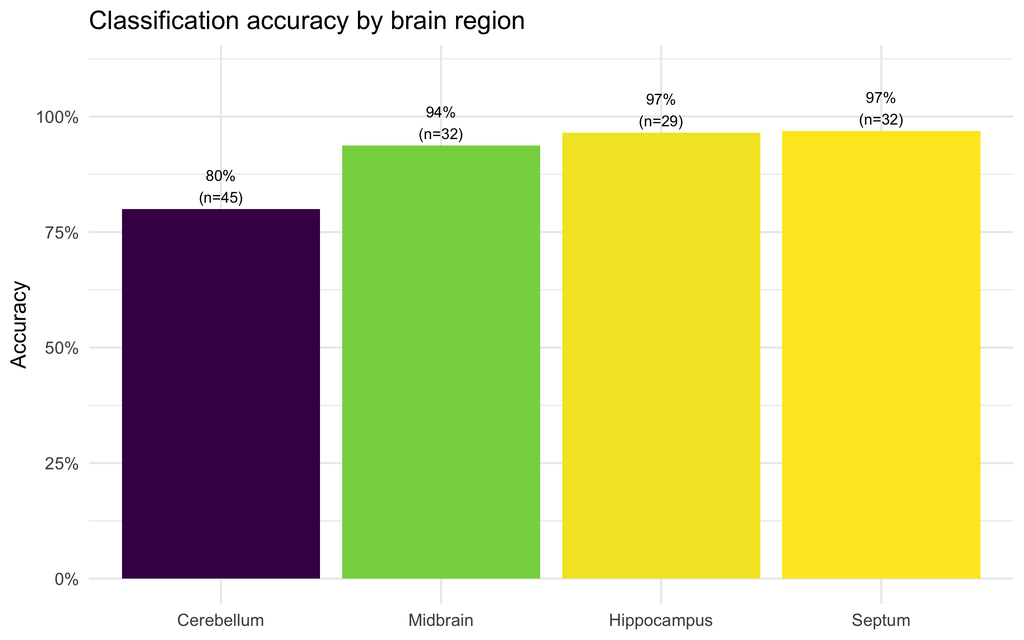

```r
p1 <- accuracy_by_region %>%
  mutate(brain_region = fct_reorder(str_to_title(brain_region), accuracy)) %>%
  ggplot(aes(brain_region, accuracy, fill = accuracy)) +
  geom_col() +
  geom_text(aes(label = sprintf("%.0f%%\n(n=%d)", 100*accuracy, total)),
            vjust = -0.2, size = 3) +
  scale_y_continuous(labels = percent, limits = c(0, 1.1), breaks = seq(0,1,.25)) +
  scale_fill_viridis_c(option = "D", guide = "none") +
  labs(title = "Classification accuracy by brain region",
       x = NULL, y = "Accuracy")
p1; save_plot(p1, "01_accuracy_by_region.png")
```

## 11.2 2. Accuracy by brain region and group

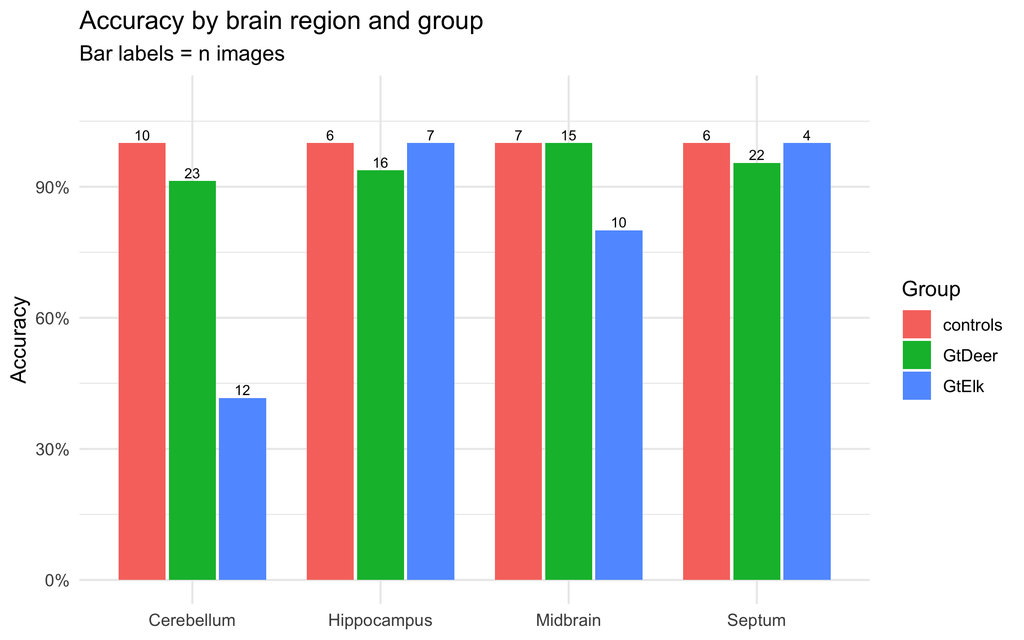

```r
p2 <- accuracy_by_group_region %>%
  ggplot(aes(str_to_title(brain_region), accuracy, fill = experimental_group)) +
  geom_col(position = position_dodge(0.8), width = 0.75) +
  geom_text(aes(label = total), position = position_dodge(0.8),
            vjust = -0.3, size = 2.8) +
  scale_y_continuous(labels = percent, limits = c(0, 1.1)) +
  labs(title = "Accuracy by brain region and group",
       subtitle = "Bar labels = n images", x = NULL, y = "Accuracy",
       fill = "Group")
p2; save_plot(p2, "02_accuracy_by_group_region.png")
```

## 11.3 3. Heatmap of accuracy (group × region)

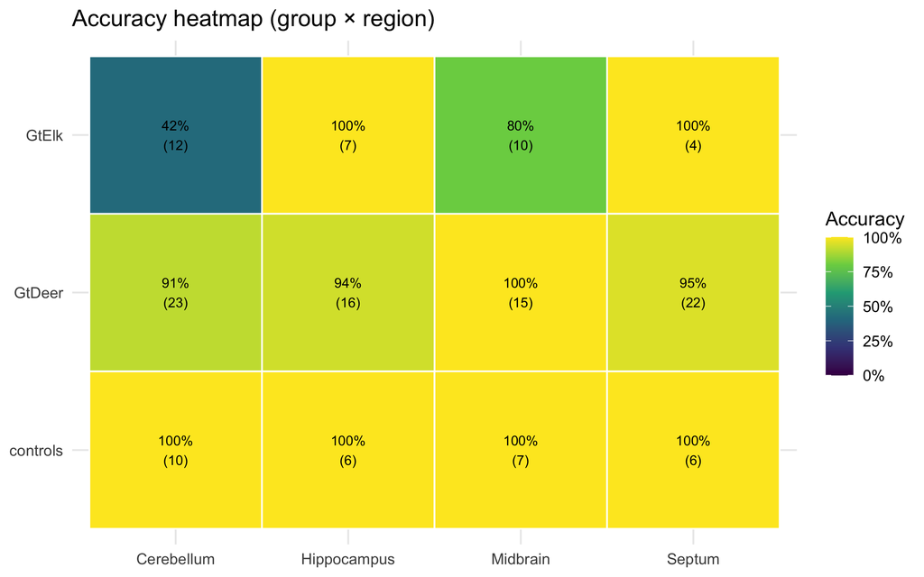

```r
p3 <- accuracy_by_group_region %>%
  ggplot(aes(str_to_title(brain_region), experimental_group, fill = accuracy)) +
  geom_tile(color = "white", linewidth = 0.5) +
  geom_text(aes(label = sprintf("%.0f%%\n(%d)", 100*accuracy, total)), size = 3) +
  scale_fill_viridis_c(option = "D", labels = percent, limits = c(0,1)) +
  labs(title = "Accuracy heatmap (group × region)",
       x = NULL, y = NULL, fill = "Accuracy")
p3; save_plot(p3, "03_heatmap_accuracy.png")
```

## 11.4 4. Heatmap of disease-indicative score (group × region)

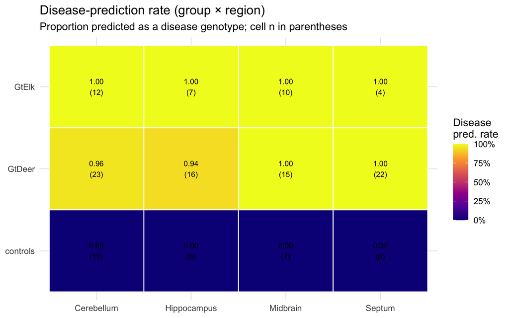

```r
# Use the categorical disease-prediction rate per cell for the group x region heatmap.
p4 <- disease_rate_cells %>%
  ggplot(aes(str_to_title(brain_region), experimental_group, fill = disease_prediction_rate)) +
  geom_tile(color = "white", linewidth = 0.5) +
  geom_text(aes(label = sprintf("%.2f\n(%d)", disease_prediction_rate, n)), size = 3) +
  scale_fill_viridis_c(option = "C", labels = percent, limits = c(0,1)) +
  labs(title = "Disease-prediction rate (group × region)",
       subtitle = "Proportion predicted as a disease genotype; cell n in parentheses",
       x = NULL, y = NULL, fill = "Disease\npred. rate")
p4; save_plot(p4, "04_heatmap_disease_score.png")
```

## 11.5 5. Ranked plot of regions by disease-indicative score

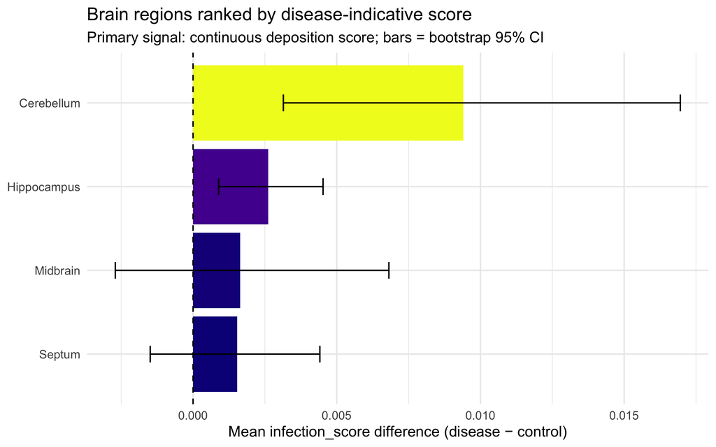

```r
# Primary ranking: continuous infection_score contrast if available, else categorical.
if (!is.na(infection_col) && "inf_score_diff" %in% names(disease_indicative_scores)) {
  rank_df <- disease_indicative_scores %>%
    transmute(brain_region, score = inf_score_diff,
              lo = inf_ci_lower, hi = inf_ci_upper)
  ylab <- "Mean infection_score difference (disease − control)"
  subt <- "Primary signal: continuous deposition score; bars = bootstrap 95% CI"
} else {
  rank_df <- disease_indicative_scores %>%
    transmute(brain_region, score = score_combined_vs_control, lo = NA, hi = NA)
  ylab <- "Disease-prediction rate difference (disease − control)"
  subt <- "Categorical fallback signal"
}

p5 <- rank_df %>%
  mutate(brain_region = fct_reorder(str_to_title(brain_region), score)) %>%
  ggplot(aes(score, brain_region)) +
  geom_col(aes(fill = score)) +
  { if (all(!is.na(rank_df$lo))) geom_errorbarh(aes(xmin = lo, xmax = hi), height = .2) } +
  geom_vline(xintercept = 0, linetype = "dashed") +
  scale_fill_viridis_c(option = "C", guide = "none") +
  labs(title = "Brain regions ranked by disease-indicative score",
       subtitle = subt, x = ylab, y = NULL)
p5; save_plot(p5, "05_ranked_disease_score.png")
```

## 11.6 6. Confusion matrix (true × predicted)

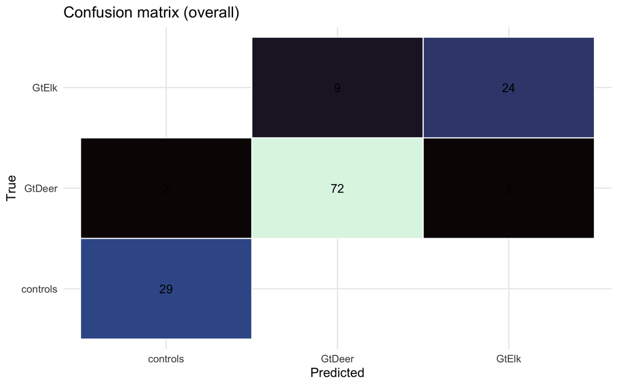

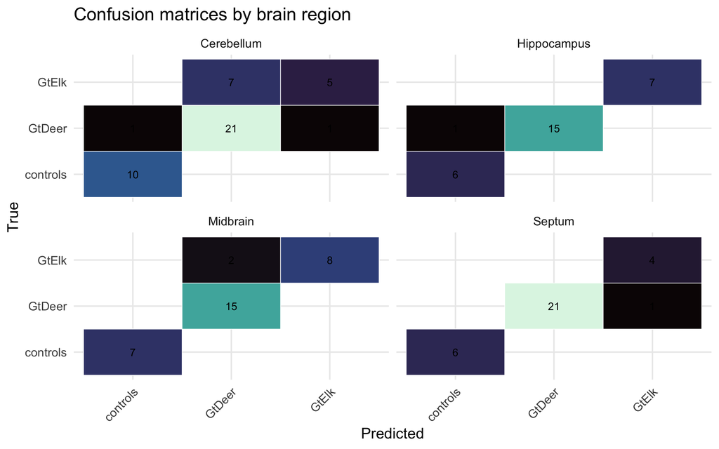

```r
if (!is.na(true_col) && !is.na(pred_col)) {
  conf_df <- df_clean %>%
    count(truth = .data[[true_col]], prediction = .data[[pred_col]])
  p6 <- conf_df %>%
    ggplot(aes(prediction, truth, fill = n)) +
    geom_tile(color = "white", linewidth = 0.5) +
    geom_text(aes(label = n), size = 4) +
    scale_fill_viridis_c(option = "G", guide = "none") +
    labs(title = "Confusion matrix (overall)", x = "Predicted", y = "True")
  print(p6); save_plot(p6, "06_confusion_matrix.png")

  # Optional per-region small multiples
  p6b <- df_clean %>%
    count(brain_region, truth = .data[[true_col]], prediction = .data[[pred_col]]) %>%
    ggplot(aes(prediction, truth, fill = n)) +
    geom_tile(color = "white") + geom_text(aes(label = n), size = 3) +
    facet_wrap(~ str_to_title(brain_region)) +
    scale_fill_viridis_c(option = "G", guide = "none") +
    labs(title = "Confusion matrices by brain region",
         x = "Predicted", y = "True") +
    theme(axis.text.x = element_text(angle = 45, hjust = 1))
  print(p6b); save_plot(p6b, "06b_confusion_by_region.png", height = 6)
}
```

## 11.7 7. Image counts per region (reliability context)

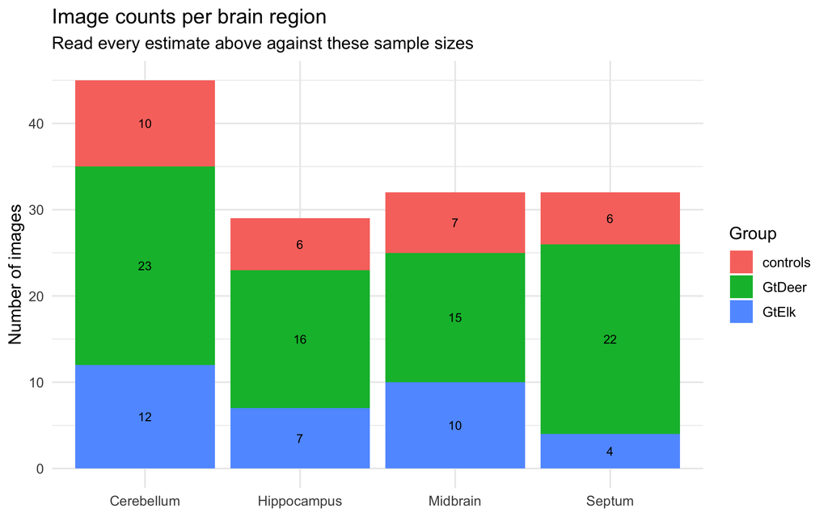

```r
p7 <- df_clean %>%
  count(brain_region, experimental_group) %>%
  ggplot(aes(str_to_title(brain_region), n, fill = experimental_group)) +
  geom_col(position = "stack") +
  geom_text(aes(label = n), position = position_stack(vjust = .5), size = 3) +
  labs(title = "Image counts per brain region",
       subtitle = "Read every estimate above against these sample sizes",
       x = NULL, y = "Number of images", fill = "Group")
p7; save_plot(p7, "07_image_counts.png")
```

# 12 Summary tables

```r
show_tbl <- function(x, caption) {
  if (have_knitr) knitr::kable(x, digits = 3, caption = caption) else x
}
show_tbl(accuracy_by_region, "Accuracy by brain region")
```

Accuracy by brain region

| brain_region | total | n_correct | n_incorrect | accuracy | error_rate |
| --- | --- | --- | --- | --- | --- |
| septum | 32 | 31 | 1 | 0.969 | 0.031 |
| hippocampus | 29 | 28 | 1 | 0.966 | 0.034 |
| midbrain | 32 | 30 | 2 | 0.938 | 0.062 |
| cerebellum | 45 | 36 | 9 | 0.800 | 0.200 |

```r
show_tbl(accuracy_by_group_region, "Accuracy by group × region")
```

Accuracy by group × region

| experimental_group | brain_region | total | n_correct | n_incorrect | accuracy | error_rate |
| --- | --- | --- | --- | --- | --- | --- |
| GtDeer | midbrain | 15 | 15 | 0 | 1.000 | 0.000 |
| GtElk | hippocampus | 7 | 7 | 0 | 1.000 | 0.000 |
| GtElk | septum | 4 | 4 | 0 | 1.000 | 0.000 |
| controls | cerebellum | 10 | 10 | 0 | 1.000 | 0.000 |
| controls | hippocampus | 6 | 6 | 0 | 1.000 | 0.000 |
| controls | midbrain | 7 | 7 | 0 | 1.000 | 0.000 |
| controls | septum | 6 | 6 | 0 | 1.000 | 0.000 |
| GtDeer | septum | 22 | 21 | 1 | 0.955 | 0.045 |
| GtDeer | hippocampus | 16 | 15 | 1 | 0.938 | 0.062 |
| GtDeer | cerebellum | 23 | 21 | 2 | 0.913 | 0.087 |
| GtElk | midbrain | 10 | 8 | 2 | 0.800 | 0.200 |
| GtElk | cerebellum | 12 | 5 | 7 | 0.417 | 0.583 |

```r
show_tbl(disease_indicative_scores, "Disease-indicative scores by region")
```

Disease-indicative scores by region

| brain_region | rate_GtDeer | rate_GtElk | rate_disease_combined | rate_control | score_GtDeer_vs_control | score_GtElk_vs_control | score_combined_vs_control | mean_inf_disease | mean_inf_control | inf_score_diff | inf_ci_lower | inf_ci_upper |
| --- | --- | --- | --- | --- | --- | --- | --- | --- | --- | --- | --- | --- |
| cerebellum | 0.957 | 1 | 0.971 | 0 | 0.957 | 1 | 0.971 | 0.012 | 0.003 | 0.009 | 0.003 | 0.017 |
| hippocampus | 0.938 | 1 | 0.957 | 0 | 0.938 | 1 | 0.957 | 0.003 | 0.000 | 0.003 | 0.001 | 0.005 |
| midbrain | 1.000 | 1 | 1.000 | 0 | 1.000 | 1 | 1.000 | 0.003 | 0.002 | 0.002 | -0.003 | 0.007 |
| septum | 1.000 | 1 | 1.000 | 0 | 1.000 | 1 | 1.000 | 0.003 | 0.001 | 0.002 | -0.001 | 0.004 |

```r
show_tbl(posthoc_pairwise_tests %>% filter(!is.na(p_value)),
         "Post-hoc pairwise tests (Fisher, BH-corrected)")
```

Post-hoc pairwise tests (Fisher, BH-corrected)

| brain_region | comparison | g1 | g2 | n_g1 | n_g2 | p_value | p_adj_BH | note |
| --- | --- | --- | --- | --- | --- | --- | --- | --- |
| cerebellum | GtDeer vs Control | GtDeer | controls | 23 | 10 | 0.000 | 0.000 |  |
| hippocampus | GtDeer vs Control | GtDeer | controls | 16 | 6 | 0.000 | 0.000 |  |
| midbrain | GtDeer vs Control | GtDeer | controls | 15 | 7 | 0.000 | 0.000 |  |
| septum | GtDeer vs Control | GtDeer | controls | 22 | 6 | 0.000 | 0.000 |  |
| cerebellum | GtDeer vs GtElk | GtDeer | GtElk | 23 | 12 | 1.000 | 1.000 | small cells |
| hippocampus | GtDeer vs GtElk | GtDeer | GtElk | 16 | 7 | 1.000 | 1.000 | small cells |
| midbrain | GtDeer vs GtElk | GtDeer | GtElk | 15 | 10 | 1.000 | 1.000 | small cells |
| septum | GtDeer vs GtElk | GtDeer | GtElk | 22 | 4 | 1.000 | 1.000 | small cells |
| cerebellum | GtElk vs Control | GtElk | controls | 12 | 10 | 0.000 | 0.000 |  |
| hippocampus | GtElk vs Control | GtElk | controls | 7 | 6 | 0.001 | 0.001 |  |
| midbrain | GtElk vs Control | GtElk | controls | 10 | 7 | 0.000 | 0.000 |  |
| septum | GtElk vs Control | GtElk | controls | 4 | 6 | 0.005 | 0.005 | small cells |

# 13 Export

```r
cleaned_path <- file.path(output_dir, "cleaned_predictions.csv")
readr::write_csv(df_clean, cleaned_path)
readr::write_csv(accuracy_by_region,        file.path(output_dir, "accuracy_by_region.csv"))
readr::write_csv(accuracy_by_group_region,  file.path(output_dir, "accuracy_by_group_region.csv"))
readr::write_csv(disease_indicative_scores, file.path(output_dir, "disease_indicative_scores.csv"))
readr::write_csv(posthoc_pairwise_tests,    file.path(output_dir, "posthoc_pairwise_tests.csv"))

cat("Wrote outputs to '", output_dir, "/':\n", sep = "")
```

```
## Wrote outputs to '../psthoc/':
```

```r
cat(" - cleaned_predictions.csv\n - accuracy_by_region.csv\n",
    "- accuracy_by_group_region.csv\n - disease_indicative_scores.csv\n",
    "- posthoc_pairwise_tests.csv\n - plots/*.png\n", sep = "")
```

```
##  - cleaned_predictions.csv
##  - accuracy_by_region.csv
## - accuracy_by_group_region.csv
##  - disease_indicative_scores.csv
## - posthoc_pairwise_tests.csv
##  - plots/*.png
```

```r
list.files(plots_dir)
```

```
## [1] "01_accuracy_by_region.png"       "02_accuracy_by_group_region.png"
## [3] "03_heatmap_accuracy.png"         "04_heatmap_disease_score.png"
## [5] "05_ranked_disease_score.png"     "06_confusion_matrix.png"
## [7] "06b_confusion_by_region.png"     "07_image_counts.png"
```